# Navigating menopause at work: A preliminary study about challenges and support systems

### 6.2.3. About your job

Third, we summarize the sample characteristics as evaluated in the ‘About your job’ section of the survey.

```r
# selecting variables
p <- data.frame(Variable=c("job_level","weeklyWorkHours","NightShift_onCall","remote_work"))

# computing descriptives
for(i in 1:nrow(p)){
  if(p[i,"Variable"]=="weeklyWorkHours"){ p[i,"Descr"] <- paste0(round(mean(mp$weeklyWorkHours,na.rm=TRUE),2),
                                                                 " (",round(sd(mp$weeklyWorkHours,na.rm=TRUE),2),")")
  } else { na.incl <- length(summary(mp[,p[i,"Variable"]])) == nlevels(mp[,p[i,"Variable"]])
    if(na.incl==TRUE) {
      p[i,"Descr"] <- paste0(levels(mp[,p[i,"Variable"]])," ",
                                 round(100*summary(mp[,p[i,"Variable"]])/nrow(mp),2),"%",collapse=", ")
    } else { p[i,"Descr"] <- paste0(c(levels(mp[,p[i,"Variable"]]),NA)," ",
                                 round(100*summary(mp[,p[i,"Variable"]])/nrow(mp),2),"%",collapse=", ") } }}

# printing descriptives
knitr::kable(p)
```

| Variable | Descr |
| --- | --- |
| job_level | Employee 32.76%, Executive 16.52%, Manager 23.36%, Other 4.27%, Self-employed 13.96%, NA 9.12% |
| weeklyWorkHours | 40.25 (10.74) |
| NightShift_onCall | No 74.07%, Yes 16.81%, NA 9.12% |
| remote_work | Hybrid 34.76%, Onsite 24.79%, Remote 31.34%, NA 9.12% |

```r
# occupational groups
cat("Occupational groups in the sample (%):"); round(100*summary(mp$job_recoded)[order(summary(mp$job_recoded),
                                                                                       decreasing=TRUE)]/nrow(mp),2)
```

```
## Occupational groups in the sample (%):
```

```
##                   production and specialised services managers
##                                                          11.11
##            business and administration associate professionals
##                                                           9.97
##                                                           NA's
##                                                           9.69
##                                           health professionals
##                                                           8.55
##                                         teaching professionals
##                                                           8.26
##                       legal, social and cultural professionals
##                                                           7.41
##                          science and engineering professionals
##                                                           7.41
##             chief executives, senior officials and legislators
##                                                           7.12
##                      business and administration professionals
##                                                           6.55
##                         administrative and commercial managers
##                                                           5.70
##        information and communications technology professionals
##                                                           5.13
##                science and engineering associate professionals
##                                                           3.13
##                                 health associate professionals
##                                                           2.56
##    legal, social, cultural and related associate professionals
##                                                           1.71
##                                       customer services clerks
##                                                           1.42
##                                       personal service workers
##                                                           1.14
##                                                  sales workers
##                                                           1.14
##                                          personal care workers
##                                                           0.57
##                             drivers and mobile plant operators
##                                                           0.28
##                                handicraft and printing workers
##                                                           0.28
## labourers in mining, construction, manufacturing and transport
##                                                           0.28
##                        numerical and material recording clerks
##                                                           0.28
##                                 other clerical support workers
##                                                           0.28
##                                           cleaners and helpers
##                                                           0.00
##                hospitality, retail and other services managers
##                                                           0.00
##                     information and communications technicians
##                                                           0.00
##                   market-oriented skilled agricultural workers
##                                                           0.00
##                   production and specialized services managers
##                                                           0.00
```

### 6.2.4. Menopause & work

```r
# computing univariate descriptives
variables <- c("MRS","mrs.psy","mrs.som","mrs.uro","MF","WL","WE","EE","TI") # selecting variables
descr <- as.data.frame(matrix(nrow=0,ncol=3)) # empty table to be filled with values
for(variable in variables){ # computing values
  descr <- rbind(descr,
                 data.frame(meansd=paste0(round(mean(mp[,variable],na.rm=T),2)," (",round(sd(mp[,variable],na.rm=T),2),")"))) }
descr <- cbind(Variable=c("MRS total score (0-44)","MRS psychological (0-16)","MRS somatic (0-16)", # adding variable names
                          "MRS urogenital (0-12)","Mental fog (0-4)","Workload (1-5)","Work engagement (0-6)",
                          "Emotional exhaustion (1-5)","Turnover intentions (1-7)"),descr)

# showing univaraite descriptives
knitr::kable(descr)
```

| Variable | meansd |
| --- | --- |
| MRS total score (0-44) | 15.3 (7.72) |
| MRS psychological (0-16) | 6.04 (3.6) |
| MRS somatic (0-16) | 5.4 (3.06) |
| MRS urogenital (0-12) | 3.86 (2.8) |
| Mental fog (0-4) | 1.18 (0.94) |
| Workload (1-5) | 3.36 (1.09) |
| Work engagement (0-6) | 3.45 (1.26) |
| Emotional exhaustion (1-5) | 3.03 (0.8) |
| Turnover intentions (1-7) | 2.64 (1.92) |

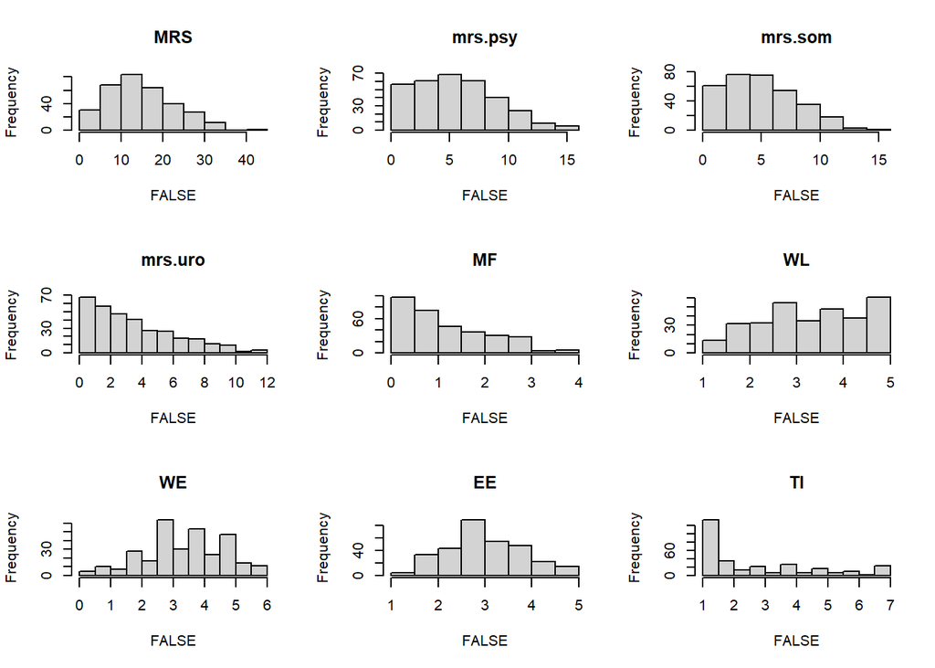

```r
# plotting distributions
par(mfrow=c(3,3))
for(variable in variables){ hist(mp[,variable],main=variable,xlab=FALSE) }
```

```r
# MRS and MF negative impact on work life
cat("MRS negative impact on work life: mean =",
    round(mean(mp$mrs_impact,na.rm=T),2),", SD =",round(sd(mp$mrs_impact,na.rm=T),2))
```

```
## MRS negative impact on work life: mean = 2.62 , SD = 1.06
```

```r
cat("MF negative impact on work life: mean =",
    round(mean(mp$mf_impact,na.rm=T),2),", SD =",round(sd(mp$mf_impact,na.rm=T),2))
```

```
## MF negative impact on work life: mean = 2.52 , SD = 1.18
```

```r
# Menopause knowledge
cat("Menopause knowledge: mean =",
    round(mean(mp$MP_knowledge,na.rm=T),2),", SD =",round(sd(mp$MP_knowledge,na.rm=T),2))
```

```
## Menopause knowledge: mean = 1.99 , SD = 0.97
```

#### 6.2.4.1. MRS categories

For the Menopause Rating Scale, in addition to considering the severity scores as continuous, we also apply the reference values proposed by Heinemann et al. (2004) to identify MSR symptom categories for the total score and each subscale.

```r
# total score
mp[!is.na(mp$MRS) & mp$MRS <= 4,"mrs.cat"] <- "no-little"
mp[!is.na(mp$MRS) & mp$MRS >= 5,"mrs.cat"] <- "mild"
mp[!is.na(mp$MRS) & mp$MRS >= 9 ,"mrs.cat"] <- "moderate"
mp[!is.na(mp$MRS) & mp$MRS >= 17,"mrs.cat"] <- "severe"

# psy
mp[!is.na(mp$mrs.psy) & mp$mrs.psy <= 1,"mrs.cat.psy"] <- "no-little"
mp[!is.na(mp$mrs.psy) & mp$mrs.psy >= 2,"mrs.cat.psy"] <- "mild"
mp[!is.na(mp$mrs.psy) & mp$mrs.psy >= 4,"mrs.cat.psy"] <- "moderate"
mp[!is.na(mp$mrs.psy) & mp$mrs.psy >= 7,"mrs.cat.psy"] <- "severe"

# som
mp[!is.na(mp$mrs.som) & mp$mrs.som <= 2,"mrs.cat.som"] <- "no-little"
mp[!is.na(mp$mrs.som) & mp$mrs.som >= 3,"mrs.cat.som"] <- "mild"
mp[!is.na(mp$mrs.som) & mp$mrs.som >= 5,"mrs.cat.som"] <- "moderate"
mp[!is.na(mp$mrs.som) & mp$mrs.som >= 9,"mrs.cat.som"] <- "severe"

# uro
mp[!is.na(mp$mrs.uro) & mp$mrs.uro == 0,"mrs.cat.uro"] <- "no-little"
mp[!is.na(mp$mrs.uro) & mp$mrs.uro == 1,"mrs.cat.uro"] <- "mild"
mp[!is.na(mp$mrs.uro) & mp$mrs.uro >= 2,"mrs.cat.uro"] <- "moderate"
mp[!is.na(mp$mrs.uro) & mp$mrs.uro >= 4,"mrs.cat.uro"] <- "severe"

# setting factor levels
p <- data.frame(Variable=c("mrs.cat",paste0("mrs.cat.",c("psy","som","uro"))))
for(Var in p$Variable){ mp[,Var] <- factor(mp[,Var],levels=c("no-little","mild","moderate","severe"))}

# showing percentages
for(i in 1:nrow(p)){
  p[i,"Descr"] <- paste0(c(levels(mp[,p[i,"Variable"]]),"NA")," ",
                         round(100*summary(mp[,p[i,"Variable"]])/nrow(mp),2),"%",collapse=", ") }
knitr::kable(p)
```

| Variable | Descr |
| --- | --- |
| mrs.cat | no-little 5.41%, mild 13.11%, moderate 38.46%, severe 35.9%, NA 7.12% |
| mrs.cat.psy | no-little 9.97%, mild 14.25%, moderate 29.06%, severe 39.6%, NA 7.12% |
| mrs.cat.som | no-little 17.38%, mild 21.94%, moderate 37.32%, severe 16.24%, NA 7.12% |
| mrs.cat.uro | no-little 8.55%, mild 10.83%, moderate 29.63%, severe 43.87%, NA 7.12% |

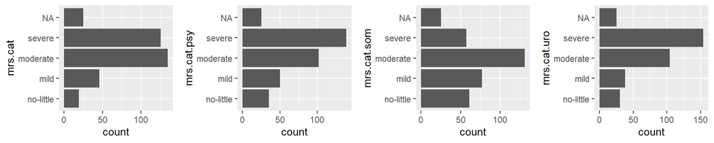

```r
# plotting
library(gridExtra)
grid.arrange(ggplot(mp,aes(mrs.cat))+geom_bar()+coord_flip(),
             ggplot(mp,aes(mrs.cat.psy))+geom_bar()+coord_flip(),
             ggplot(mp,aes(mrs.cat.som))+geom_bar()+coord_flip(),
             ggplot(mp,aes(mrs.cat.uro))+geom_bar()+coord_flip(),nrow=1)
```

### 6.2.5. Work-related problems

Fifth, we summarize the result of the `workProblems` variables, resulting from a single item requiring to indicate whether a number of work-related problems due to menopause symptoms have been experienced or not.

```r
# recoding: from Yes/No to 1/0
for(coL in paste0("workProblems_",1:9)){ mp[,coL] <- as.integer(as.character(mp[,coL])) }

# No. of responses with NO orient, min, and max
noProb <- nrow(mp[!is.na(mp$workProblems_9) & mp$workProblems_9==1,])
pnoProb <- round(100*nrow(mp[!is.na(mp$workProblems_9) &
                               mp$workProblems_9==1,])/nrow(mp[!is.na(mp$workProblems_9),]),1)
cat(noProb,"participants reporting no MP-related problems at work (",pnoProb,"% )")
```

```
## 67 participants reporting no MP-related problems at work ( 22.3 % )
```

```r
# 1+ problems
workProb <- mp[!is.na(mp$workProblems_9) & mp$workProblems_9==0,c("ID",paste0("workProblems_",1:9))]
workProb$sum <- apply(workProb[,paste0("workProblems_",1:9)],1,sum,na.rm=TRUE) # summing values
cat(nrow(workProb),"participants reported from",min(workProb$sum),"to",max(workProb$sum),"problems")
```

```
## 234 participants reported from 1 to 8 problems
```

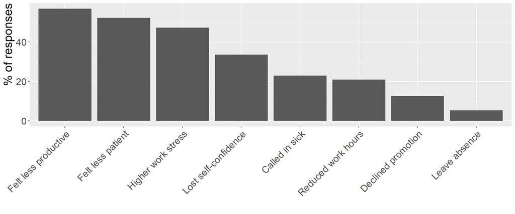

```r
# creating summary table
wpDf <- data.frame(wpCat=paste0("workProblems_",1:8),
                   n=as.numeric(t(colSums(workProb[,paste0("workProblems_",1:8)],na.rm=TRUE))))
wpDf$p <- round(100*wpDf$n/nrow(mp[!is.na(mp$workProblems_9),]),2)
wpDf$wpCat <- c("Felt less productive","Reduced work hours","Called in sick","Leave absence",
                "Felt less patient","Higher work stress","Declined promotion",
                "Lost self-confidence")
wpDf$wpCat <- factor(wpDf$wpCat,levels=wpDf$wpCat)
wpDf <- wpDf[order(wpDf$n,decreasing=TRUE),]
wpDf$wpCat <- factor(wpDf$wpCat,levels=as.character(wpDf$wpCat))

# plotting
ggplot(wpDf,aes(x=wpCat,y=p)) + geom_bar(stat="identity") +
  theme(axis.text.x=element_text(angle=45),text=element_text(size=20,hjust=1)) +
  xlab("") + ylab("% of responses")
```

```r
ggsave(file="figures/Figure4.tiff",dpi=300)

# frequency table
wpDf
```

|  | wpCat | n | p |
| --- | --- | --- | --- |
| 1 | Felt less productive | 171 | 56.81 |
| 5 | Felt less patient | 157 | 52.16 |
| 6 | Higher work stress | 142 | 47.18 |
| 8 | Lost self-confidence | 101 | 33.55 |
| 3 | Called in sick | 69 | 22.92 |
| 2 | Reduced work hours | 63 | 20.93 |
| 7 | Declined promotion | 38 | 12.62 |
| 4 | Leave absence | 16 | 5.32 |

### 6.2.6. Workplace measures

Sixth, we summarize the result of the `measures` variables, resulting from a single item requiring to indicate whether a number of workplace measures targeting menopause symptoms are considered as ‘helpful/desired’ and if they have been already implemented in the respondent’s workplace.

```r
# recoding as integer and isolating helpful and implemented measures
for(meas in paste0(rep(paste0("measures_",1:9),each=2),"_",c("helpful","implemented"))){
  mp[,meas] <- as.integer(as.character(mp[,meas]))
  colnames(mp)[which(colnames(mp)==meas)] <- paste0("meas",substr(meas,12,15),substr(meas,9,10)) }

# composite scores
mp$meashelp_sum <- apply(mp[,paste0("meashelp_",1:9)],1,sum)
mp$measimpl_sum <- apply(mp[,paste0("measimpl_",1:9)],1,sum)

# No. of responses with NO helpful measures
noHelp <- nrow(mp[!is.na(mp$meashelp_1) & mp$meashelp_sum==0,])
pnoHelp <- round(100*nrow(mp[!is.na(mp$meashelp_1) & mp$meashelp_sum==0,])/
                   nrow(mp[!is.na(mp$meashelp_1),]),2)
# No. of responses with NO implemented measures
noImpl <- nrow(mp[!is.na(mp$measimpl_1) & mp$measimpl_sum==0,])
pnoImpl <- round(100*nrow(mp[!is.na(mp$measimpl_1) & mp$measimpl_sum==0,])/
                   nrow(mp[!is.na(mp$measimpl_1),]),2)
cat(noHelp,"participants reporting no helpful measures (",pnoHelp,"% )\n",
    noImpl,"participants reporting no implemented measures (",pnoImpl,"% )")
```

```
## 32 participants reporting no helpful measures ( 10.63 % )
##  130 participants reporting no implemented measures ( 43.19 % )
```

```r
# isolating cases with 1+ responses
measHelp <- mp[!is.na(mp$meashelp_sum) & mp$meashelp_sum!=0,c("ID",paste0("meashelp_",1:9),
                                                              "meashelp_sum")]
measImpl <- mp[!is.na(mp$measimpl_sum) & mp$measimpl_sum!=0,c("ID",paste0("measimpl_",1:9),
                                                              "measimpl_sum")]
cat(nrow(measHelp),"participants reported from",
    min(measHelp$meashelp_sum,na.rm=T),"to",max(measHelp$meashelp_sum,na.rm=T),"desired measures")
```

```
## 269 participants reported from 1 to 9 desired measures
```

```r
cat(nrow(measImpl),"participants reported from",
    min(measImpl$measimpl_sum,na.rm=T),"to",max(measImpl$measimpl_sum,na.rm=T),"implemented measures")
```

```
## 171 participants reported from 1 to 9 implemented measures
```

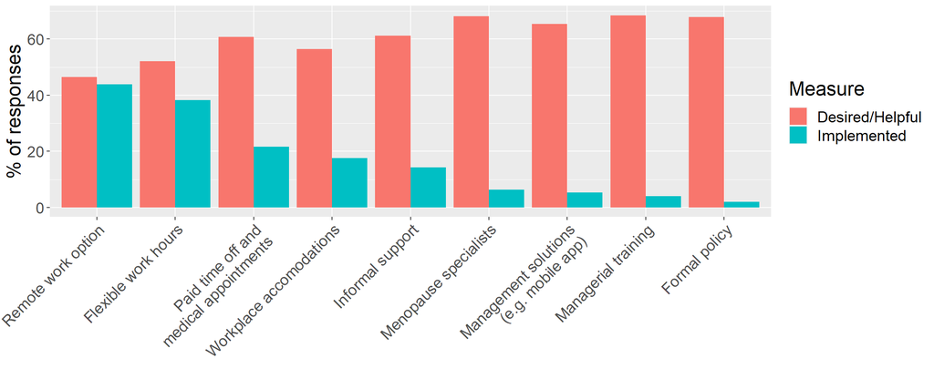

```r
# creating summary tables
helpDf <- data.frame(wpCat=paste0("meashelp_",1:9),
                     n=as.numeric(t(colSums(measHelp[,paste0("meashelp_",1:9)],na.rm=TRUE))))
helpDf$p <- round(100*helpDf$n/nrow(mp[!is.na(mp$meashelp_1),]),2)
implDf <- data.frame(wpCat=paste0("measimpl_",1:9),
                     n=as.numeric(t(colSums(measImpl[,paste0("measimpl_",1:9)],na.rm=TRUE))))
implDf$p <- round(100*implDf$n/nrow(mp[!is.na(mp$measimpl_1),]),2)

# response labels
measCat <- c("Formal policy","Managerial training","Paid time off and\nmedical appointments",
             "Flexible work hours","Remote work option","Workplace accomodations",
             "Informal support","Menopause specialists","Management solutions\n(e.g. mobile app)")
measures <- data.frame(measCat = factor(rep(measCat,2),levels=measCat),
                       Measure = c(rep("Desired/Helpful",9),rep("Implemented",9)),
                       n = c(helpDf$n, implDf$n), p = c(helpDf$p, implDf$p))
impl <- measures[measures$Measure=="Implemented",]
impl <- impl[order(impl$n,decreasing=TRUE),] # sorting labels by No. of implemented cases
measures$measCat <- factor(measures$measCat,levels=as.character(impl$measCat))

# plotting
ggplot(measures,aes(x=measCat,y=p,fill=Measure)) + geom_bar(stat="identity",position=position_dodge())+
  theme(axis.text.x=element_text(angle=45,hjust=1),text=element_text(size=18)) +
  xlab("") + ylab("% of responses")
```

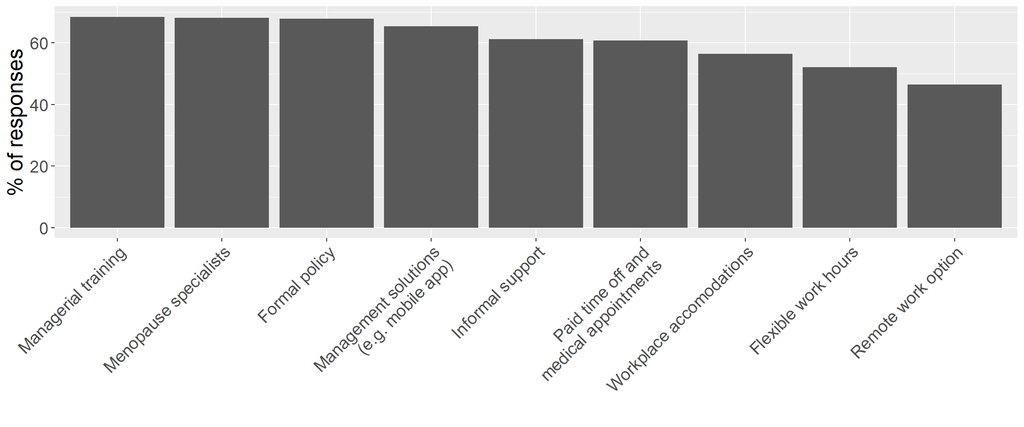

```r
ggsave(file="figures/Figure5.tiff",dpi=300)

# plotting as separate figures
des <- measures[measures$Measure=="Desired/Helpful",]
des <- des[order(des$n,decreasing=TRUE),]
des$measCat <- factor(des$measCat,levels=as.character(des$measCat))
ggplot(des,aes(x=measCat,y=p)) + geom_bar(stat="identity",position=position_dodge())+
  theme(axis.text.x=element_text(angle=45,hjust=1),text=element_text(size=18)) +
  xlab("") + ylab("% of responses")
```

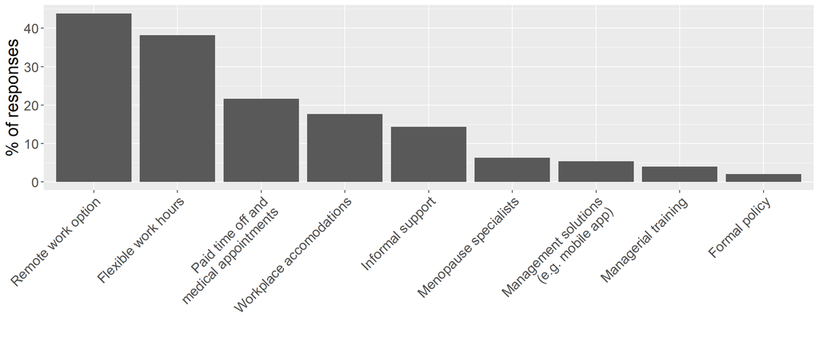

```r
ggsave(file="figures/Figure5_desired.tiff",dpi=300)
ggplot(measures[measures$Measure=="Implemented",],aes(x=measCat,y=p)) + geom_bar(stat="identity",position=position_dodge())+
  theme(axis.text.x=element_text(angle=45,hjust=1),text=element_text(size=18)) +
  xlab("") + ylab("% of responses")
```

```r
ggsave(file="figures/Figure5_implemented.tiff",dpi=300)

# frequency table
measures
```

| measCat | Measure | n | p |
| --- | --- | --- | --- |
| Formal policy | Desired/Helpful | 204 | 67.77 |
| Managerial training | Desired/Helpful | 206 | 68.44 |
| Paid time off and\nmedical appointments | Desired/Helpful | 183 | 60.80 |
| Flexible work hours | Desired/Helpful | 157 | 52.16 |
| Remote work option | Desired/Helpful | 140 | 46.51 |
| Workplace accomodations | Desired/Helpful | 170 | 56.48 |
| Informal support | Desired/Helpful | 184 | 61.13 |
| Menopause specialists | Desired/Helpful | 205 | 68.11 |
| Management solutions\n(e.g. mobile app) | Desired/Helpful | 197 | 65.45 |
| Formal policy | Implemented | 6 | 1.99 |

[output cut: 8 more lines]

### 6.2.7. Concerns

Fifth, we summarize the result of the `concerns` variables, resulting from a single item requiring to indicate whether a number of concerns about discussing menopause at work have been experienced or not.

```r
# recoding: from Yes/No to 1/0
for(coL in paste0("concerns_",c(1:9,0))){ mp[,coL] <- as.integer(as.character(mp[,coL])) }

# No. of responses with NO orient, min, and max
mp$concSum <- apply(mp[,paste0("concerns_",1:9)],1,sum) # summing values
mp[!is.na(mp$concSum) & mp$concSum==0,"concerns_0"] <- 1
noConc <- nrow(mp[!is.na(mp$concerns_0) & mp$concerns_0==1,])
pnoConc <- round(100*nrow(mp[!is.na(mp$concerns_0) & mp$concerns_0==1,])/nrow(mp[!is.na(mp$concerns_0),]),1)
cat(noConc,"participants reporting no concerns (",pnoConc,"% )")
```

```
## 91 participants reporting no concerns ( 30.2 % )
```

```r
# 1+ concerns
workConc <- mp[!is.na(mp$concerns_0) & mp$concerns_0==0,c("ID",paste0("concerns_",1:9))]
pConc <- round(100*nrow(workConc)/nrow(mp[!is.na(mp$concerns_0),]),2)
workConc$sum <- apply(workConc[,paste0("concerns_",1:9)],1,sum,na.rm=TRUE) # summing values
cat(nrow(workConc),"participants (",pConc,"%) reported from",min(workConc$sum),"to",max(workConc$sum),"problems")
```

```
## 210 participants ( 69.77 %) reported from 1 to 9 problems
```

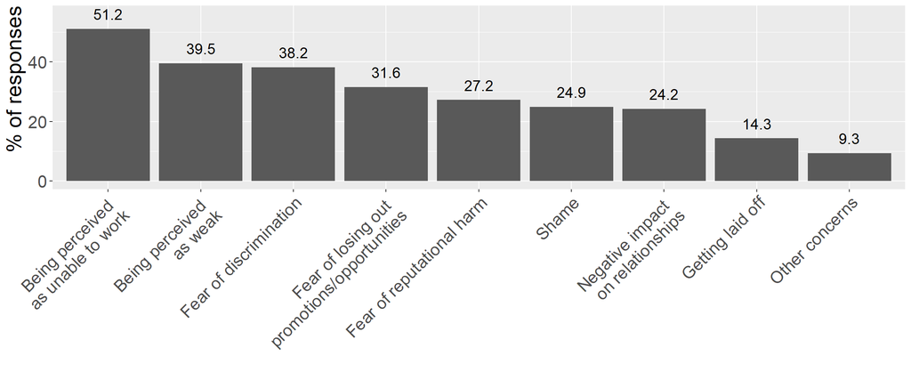

```r
# creating summary table
concDf <- data.frame(concCat=paste0("concerns_",1:9),
                   n=as.numeric(t(colSums(workConc[,paste0("concerns_",1:9)],na.rm=TRUE))))
concDf$p <- round(100*concDf$n/nrow(mp[!is.na(mp$concerns_0),]),2)
concCat <- c("Shame","Being perceived \nas unable to work","Fear of losing out \npromotions/opportunities",
             "Being perceived \nas weak","Fear of reputational harm",
             "Negative impact \non relationships","Fear of discrimination","Getting laid off","Other concerns")
concDf$concCat <- factor(concCat,levels=concCat)
concDf <- concDf[order(concDf$n,decreasing=TRUE),] # sorting by freq
concDf$concCat <- factor(as.character(concDf$concCat),levels=as.factor(concDf$concCat))

# plotting
ggplot(concDf,aes(x=concCat,y=p)) + geom_bar(stat="identity") +
  theme(axis.text.x=element_text(angle=45),text=element_text(size=20,hjust=1)) +
  geom_text(aes(y=p+5,label=round(p,1)),size=5) +
  xlab("") + ylab("% of responses")
```

```r
ggsave(file="figures/Figure6.tiff",dpi=300)

# frequency table
concDf
```

|  | concCat | n | p |
| --- | --- | --- | --- |
| 2 | Being perceived \nas unable to work | 154 | 51.16 |
| 4 | Being perceived \nas weak | 119 | 39.53 |
| 7 | Fear of discrimination | 115 | 38.21 |
| 3 | Fear of losing out \npromotions/opportunities | 95 | 31.56 |
| 5 | Fear of reputational harm | 82 | 27.24 |
| 1 | Shame | 75 | 24.92 |
| 6 | Negative impact \non relationships | 73 | 24.25 |
| 8 | Getting laid off | 43 | 14.29 |
| 9 | Other concerns | 28 | 9.30 |

## 6.3. Bivariate descriptives

Here, we provide bivariate statistics for the considered variable.

### 6.3.1. Correlations

First, we compute and plot the correlations between the considered variables by only considering complete responses (N = 301). This is done with the `corPrint` function.

**`corPrint()`**

```r
corPrint <- function(data,variables,pvalue=FALSE,correction="bonferroni"){
  require(Rmisc); require(Hmisc)

  out <- rcorr(as.matrix(data[,variables]), type = "pearson")
  rb <- round(out$r,2) # corr coefficients
  rb[upper.tri(rb)] <- NA
  rb.p <- out$P # pvalues
  rb.p[upper.tri(rb.p)] <- NA

  # correcting and adding p-values
  if(pvalue==TRUE){
    adj <- data.frame(original=rb.p[!is.na(rb.p)],sig=rep(NA,length(rb.p[!is.na(rb.p)])))
    adj$adjusted=p.adjust(adj$original,method=correction)
    # significance level
    adj[adj$adjusted<.05,"sig"] <- "*"
    adj[adj$adjusted<.01,"sig"] <- "**"
    adj[adj$adjusted<.001,"sig"] <- "***"
    adj[is.na(adj$sig),"sig"] <- ""
    for(i in 1:nrow(adj)){ rb.p[!is.na(rb.p) & rb.p==adj[i,"original"]] <- adj[i,"sig"] }
    for(i in 1:nrow(rb.p)){ for(j in 1:ncol(rb.p)){
      if(!is.na(rb.p[i,j])){ rb[i,j] <- paste(round(as.numeric(rb[i,j]),2),rb.p[i,j],sep="")
      } else { rb[i,j] <- "" }
      rb[i,j] <- gsub("0\\.",".",rb[i,j]) }} }
  return(rb)}
```

```r
# computing correlations
cors <- corPrint(mp,variables,pvalue=TRUE,correction="bonferroni")
knitr::kable(cors)
```

|  | MRS | mrs.psy | mrs.som | mrs.uro | MF | WL | WE | EE | TI |
| --- | --- | --- | --- | --- | --- | --- | --- | --- | --- |
| MRS |  |  |  |  |  |  |  |  |  |
| mrs.psy | .85*** |  |  |  |  |  |  |  |  |
| mrs.som | .85*** | .6*** |  |  |  |  |  |  |  |
| mrs.uro | .74*** | .39*** | .49*** |  |  |  |  |  |  |
| MF | .65*** | .69*** | .48*** | .38*** |  |  |  |  |  |
| WL | .25*** | .26*** | .21** | .11 | .12 |  |  |  |  |
| WE | -.27*** | -.37*** | -.19* | -.07 | -.36*** | .1 |  |  |  |
| EE | .47*** | .56*** | .34*** | .2* | .39*** | .57*** | -.43*** |  |  |
| TI | .18 | .24** | .15 | .01 | .2* | .15 | -.45*** | .45*** |  |

Here, the same correlations are visualized in a heat diagram.

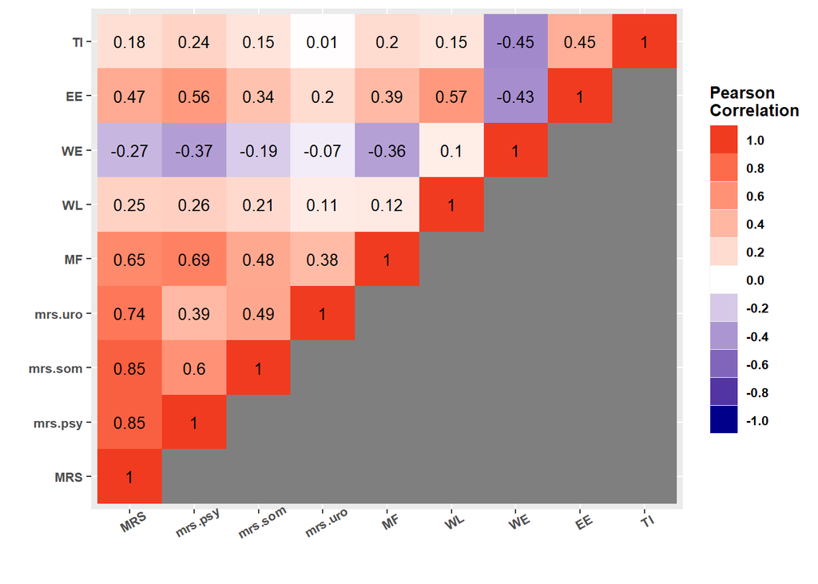

```r
ggplot(melt(t(as.matrix(corPrint(mp,variables)))),
       aes(x=Var1, y=Var2, fill=value)) + geom_tile() +
  geom_text(aes(x = Var1, y = Var2, label = round(value,2)),color="black",size=3.5)+labs(x="",y="") +
  scale_fill_gradient2(low="darkblue",high="#f03b20",mid="white",midpoint=0,limit = c(-1,1), space = "Lab",
                       name="Pearson\nCorrelation",guide="legend",breaks=round(seq(1,-1,length.out = 11),2),
                       minor_breaks=round(seq(1,-1,length.out = 11),2))+
  theme(text=element_text(face="bold",size=10),axis.text.x=element_text(angle=30))
```

## 6.4. Output table

The table below shows the univariate descriptive statistics of, and the correlations between, the considered measures.

```r
table2 <- cbind(descr,cors)
table2$Variable <- paste0(1:nrow(table2),". ",table2$Variable)
colnames(table2)[3:ncol(table2)] <- paste0(1:length(variables),".")
knitr::kable(table2,row.names=FALSE)
```

| Variable | meansd | 1. | 2. | 3. | 4. | 5. | 6. | 7. | 8. | 9. |
| --- | --- | --- | --- | --- | --- | --- | --- | --- | --- | --- |
| 1. MRS total score (0-44) | 15.3 (7.72) |  |  |  |  |  |  |  |  |  |
| 2. MRS psychological (0-16) | 6.04 (3.6) | .85*** |  |  |  |  |  |  |  |  |
| 3. MRS somatic (0-16) | 5.4 (3.06) | .85*** | .6*** |  |  |  |  |  |  |  |
| 4. MRS urogenital (0-12) | 3.86 (2.8) | .74*** | .39*** | .49*** |  |  |  |  |  |  |
| 5. Mental fog (0-4) | 1.18 (0.94) | .65*** | .69*** | .48*** | .38*** |  |  |  |  |  |
| 6. Workload (1-5) | 3.36 (1.09) | .25*** | .26*** | .21** | .11 | .12 |  |  |  |  |
| 7. Work engagement (0-6) | 3.45 (1.26) | -.27*** | -.37*** | -.19* | -.07 | -.36*** | .1 |  |  |  |
| 8. Emotional exhaustion (1-5) | 3.03 (0.8) | .47*** | .56*** | .34*** | .2* | .39*** | .57*** | -.43*** |  |  |
| 9. Turnover intentions (1-7) | 2.64 (1.92) | .18 | .24** | .15 | .01 | .2* | .15 | -.45*** | .45*** |  |

# 7. Regression models

Here, we fit multiple regression models to test our hypotheses on the relationship between MRS scores and work-related experience, namely emotional exhaustion, work engagement, and turnover intentions. For each outcome, we fit a separate set of regression models in a hierarchical manner:

1. Null model (intercept-only)
2. Model including menopause symptoms severity `MRS` as a predictor
3. Model also including workload `WL` as a predictor
4. Model also including further covariates, namely `age`, `caregiving`*, menopause hormonal therapy `MHT`, and `health_condition` as covariates

*`caregiving` is recoded as “Yes” when a participant reported either taking care of an adult or taking care of children, and “No” when neither one nor the other condition apply.

```r
# packages used in the regression analyses
library(MuMIn); library(sjPlot)

# renaming mp hormonal theraphy as MHT
colnames(mp)[which(colnames(mp)=="rs_MP_hormTheraphy")] <- "MHT"

# recoding caregiving
mp[!is.na(mp$caregiver) & !is.na(mp$childcare) &
     (mp$caregiver=="Yes" | mp$childcare=="Yes"),"caregiving"] <- "Yes"
mp[!is.na(mp$caregiver) & !is.na(mp$childcare) &
     (mp$caregiver=="No" & mp$childcare=="No"),"caregiving"] <- "No"
mp$caregiving <- as.factor(mp$caregiving) # as factor
cat("Caregiving (recoded):")
```

```
## Caregiving (recoded):
```

```r
summary(mp$caregiving)
```

```
##   No  Yes NA's
##  161  189    1
```

## 7.1. Emotional exhaustion

First, we specify our models in a hierarchical manner on the list-wise-deleted dataset. Note that all continuous predictors are grand-mean-centered for better interpreting the model intercept.

```r
# list-wise deletion (removing all missing values in the considered variables)
df <- na.omit(mp[,c("EE","MRS","WL","age","MHT","health_conditions","caregiving")])
cat("Fitting models on",nrow(df),"observations")
```

```
## Fitting models on 307 observations
```

```r
# grand mean centering continuous predictors
df$MRS <- df$MRS - mean(df$MRS)
df$WL <- df$WL - mean(df$WL)
df$age <- df$age - mean(df$age)

# null model (no predictors)
EE.m0 <- lm(EE ~ 1, data = df)

# model M1 (menopause symptom severity)
EE.m1 <- lm(EE ~ MRS, data = df)

# model M2 (workload as a job demand)
EE.m2 <- lm(EE ~ MRS + WL, data = df)

# model M3 (covariates)
EE.m3 <- lm(EE ~ MRS + WL + age + MHT + health_conditions + caregiving, data = df)
```

Second, we inspect the diagnostics of the most complex model. Linear model assumptions seem to be met by the examined model: residuals are normally distributed and centered on zero, residuals and their variance seem quite constant over fitted values, and VIF indicate low risk for multicollinearity.

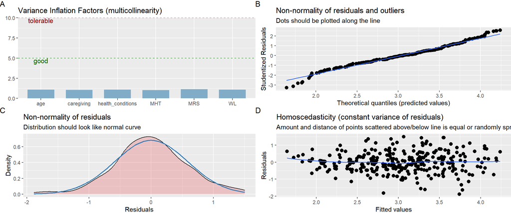

```r
p <- plot_model(EE.m3,type="diag")
plot_grid(p,tags=TRUE,margin=c(0,0,0,0))
```

As a further diagnostic, we examine the impact of influential cases (i.e., based on the Cook’s distance) on the parameter estimated for `MRS.` We can see that several influential cases are detected, but none of them seem to substantially change the parameter estimated for `MRS`.

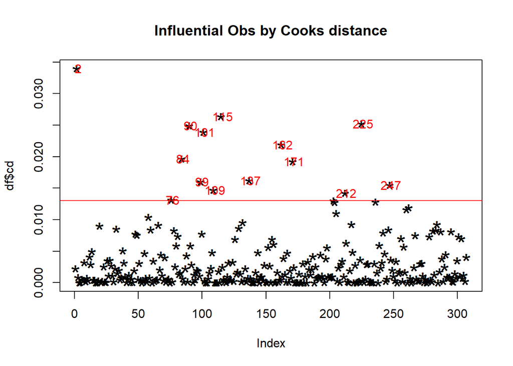

```r
# Cook's distances
df$cd <- cooks.distance(EE.m3)

# Plot the Cook's Distance using the traditional 4/n criterion
rownames(df) <- 1:nrow(df)
plot(df$cd, pch="*", cex=2, main="Influential Obs by Cooks distance")  # plot cook's distance
abline(h = 4/nrow(df), col="red")  # add cutoff line
text(x=1:nrow(df)+1, y=df$cd, labels=ifelse(df$cd>4/nrow(df), rownames(df),""), col="red")  # add labels
```

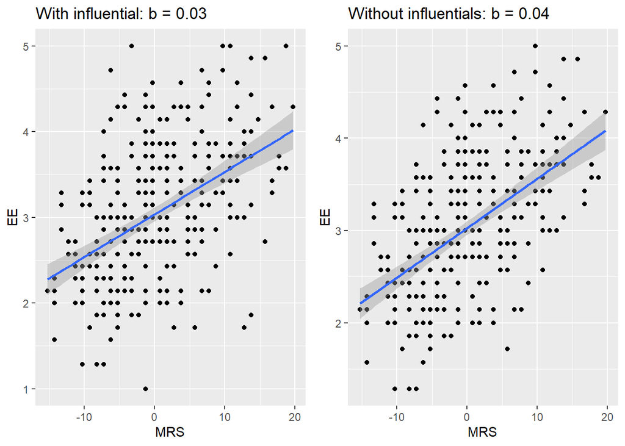

```r
# plotting effects with and without influential cases
influential <- as.integer(rownames(df[df$cd > (4/nrow(df)),]))
df2 <- df[-influential, ] # removing influential cases
p1 <- ggplot(data = df, aes(x = MRS, y = EE)) + geom_point() + geom_smooth(method = lm) +
  ggtitle(paste0("With influential: b = ",round(coefficients(EE.m3)[2],2)))
p2 <- ggplot(data = df2, aes(x = MRS, y = EE)) + geom_point() + geom_smooth(method = lm) +
  ggtitle(paste0("Without influentials: b = ",round(coefficients(update(EE.m3,data=df2))[2],2)))
gridExtra::grid.arrange(p1, p2, ncol=2)
```

Third, we compare the models by using the weight of the Akaike Information Criterion (Wagenmakers & Ferrel, 2004).

```r
Weights(AIC(EE.m0,EE.m1,EE.m2,EE.m3)) # model M3 is the best model
```

```
##  model weights
## [1] 0.000 0.000 0.066 0.934
```

Fourth, we inspect the parameter estimated by each model. We can see that `MRS` is significantly related to `EE` consistently across the four models. Particularly, its inclusion in the null model is associated with an $R^2$ of .22 (i.e., explaining 22% of `EE` variance).

```r
# print model output
tab_model(EE.m0,EE.m1,EE.m2,EE.m3, # all significant but health_conditions
          show.se=TRUE,collapse.se=TRUE,string.est="B (SE)",show.re.var = TRUE)
```

|  | EE |  |  | EE |  |  | EE |  |  | EE |  |  |
| --- | --- | --- | --- | --- | --- | --- | --- | --- | --- | --- | --- | --- |
| Predictors | B (SE) | CI | p | B (SE) | CI | p | B (SE) | CI | p | B (SE) | CI | p |
| (Intercept) | 3.03 (0.05) | 2.94 – 3.12 | **<0.001** | 3.03 (0.04) | 2.95 – 3.11 | **<0.001** | 3.03 (0.03) | 2.97 – 3.10 | **<0.001** | 3.01 (0.06) | 2.89 – 3.12 | **<0.001** |
| MRS |  |  |  | 0.05 (0.01) | 0.04 – 0.06 | **<0.001** | 0.04 (0.00) | 0.03 – 0.05 | **<0.001** | 0.03 (0.00) | 0.03 – 0.04 | **<0.001** |
| WL |  |  |  |  |  |  | 0.35 (0.03) | 0.29 – 0.42 | **<0.001** | 0.36 (0.03) | 0.30 – 0.42 | **<0.001** |
| age |  |  |  |  |  |  |  |  |  | -0.02 (0.01) | -0.03 – -0.01 | **0.004** |
| MHT [1] |  |  |  |  |  |  |  |  |  | -0.04 (0.10) | -0.23 – 0.15 | 0.664 |
| health conditions [Yes] |  |  |  |  |  |  |  |  |  | 0.13 (0.07) | -0.01 – 0.27 | 0.069 |
| caregiving [Yes] |  |  |  |  |  |  |  |  |  | -0.04 (0.07) | -0.17 – 0.10 | 0.606 |
| Observations | 307 |  |  | 307 |  |  | 307 |  |  | 307 |  |  |
| R<sup>2</sup> / R<sup>2</sup> adjusted | 0.000 / 0.000 |  |  | 0.223 / 0.220 |  |  | 0.442 / 0.438 |  |  | 0.465 / 0.455 |  |  |

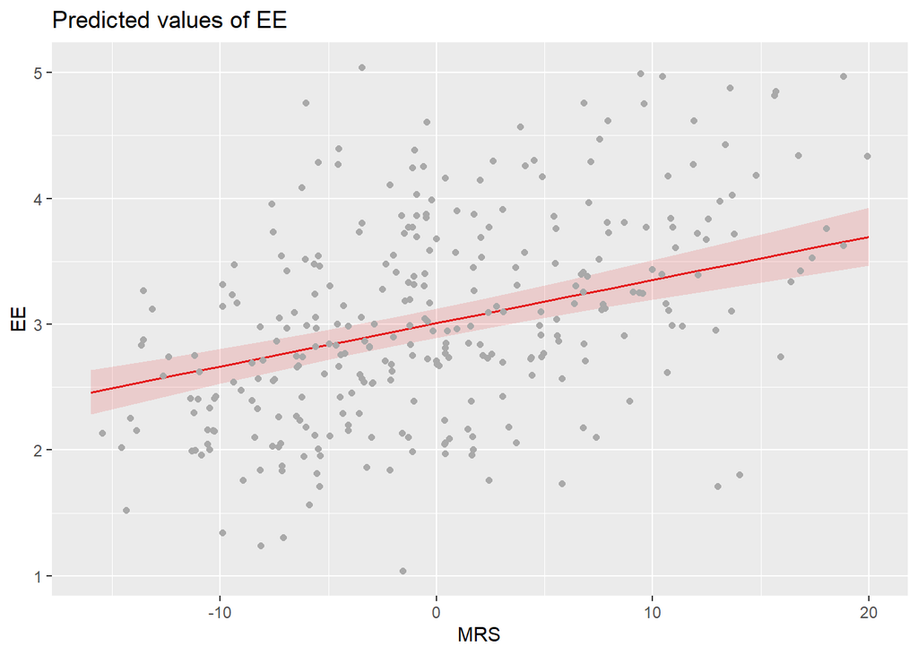

```r
# plotting MRS effect
plot_model(EE.m3,type="pred",terms="MRS") +
  geom_point(data=df,aes(x=MRS,y=EE),color="darkgray",position=position_jitter())
```

## 7.2. Work Engagement

First, we specify our models in a hierarchical manner on the list-wise-deleted dataset. Note that all continuous predictors are grand-mean-centered for better interpreting the model intercept.

```r
# list-wise deletion (removing all missing values in the considered variables)
df <- na.omit(mp[,c("WE","MRS","WL","age","MHT","health_conditions","caregiving")])
cat("Fitting models on",nrow(df),"observations")
```

```
## Fitting models on 310 observations
```

```r
# grand mean centering continuous predictors
df$MRS <- df$MRS - mean(df$MRS)
df$WL <- df$WL - mean(df$WL)
df$age <- df$age - mean(df$age)

# null model (no predictors)
WE.m0 <- lm(WE ~ 1, data = df)

# model M1 (menopause symptom severity)
WE.m1 <- lm(WE ~ MRS, data = df)

# model M2 (workload as a job demand)
WE.m2 <- lm(WE ~ MRS + WL, data = df)

# model M3 (covariates)
WE.m3 <- lm(WE ~ MRS + WL + age + MHT + health_conditions + caregiving, data = df)
```

Second, we inspect the diagnostics of the most complex model. Linear model assumptions seem to be met by the examined model: residuals are normally distributed and centered on zero, residuals and their variance seem quite constant over fitted values, and VIF indicate low risk for multicollinearity.

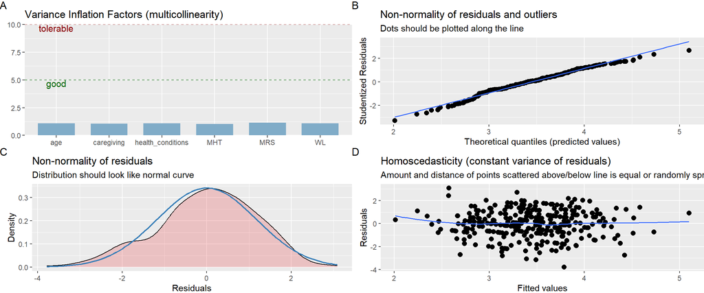

```r
p <- plot_model(WE.m3,type="diag")
plot_grid(p,tags=TRUE,margin=c(0,0,0,0))
```

As a further diagnostic, we examine the impact of influential cases (i.e., based on the Cook’s distance) on the parameter estimated for `MRS.` We can see that several influential cases are detected, but none of them seem to substantially change the parameter estimated for `MRS`.

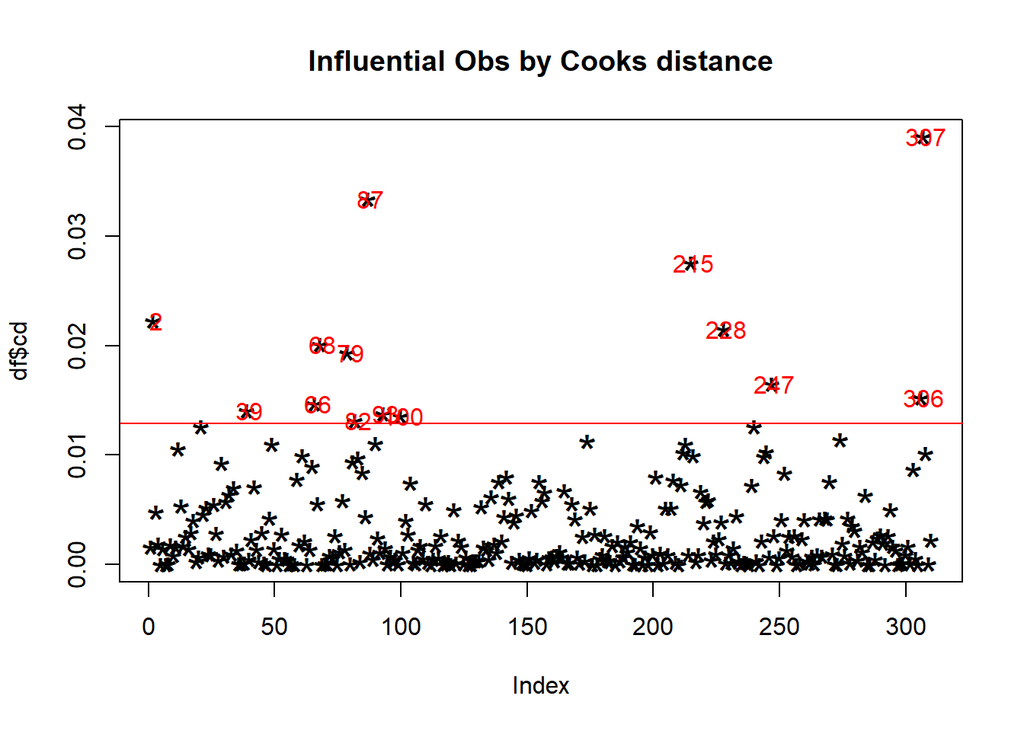

```r
# Cook's distances
df$cd <- cooks.distance(WE.m3)

# Plot the Cook's Distance using the traditional 4/n criterion
rownames(df) <- 1:nrow(df)
plot(df$cd, pch="*", cex=2, main="Influential Obs by Cooks distance")  # plot cook's distance
abline(h = 4/nrow(df), col="red")  # add cutoff line
text(x=1:nrow(df)+1, y=df$cd, labels=ifelse(df$cd>4/nrow(df), rownames(df),""), col="red")  # add labels
```

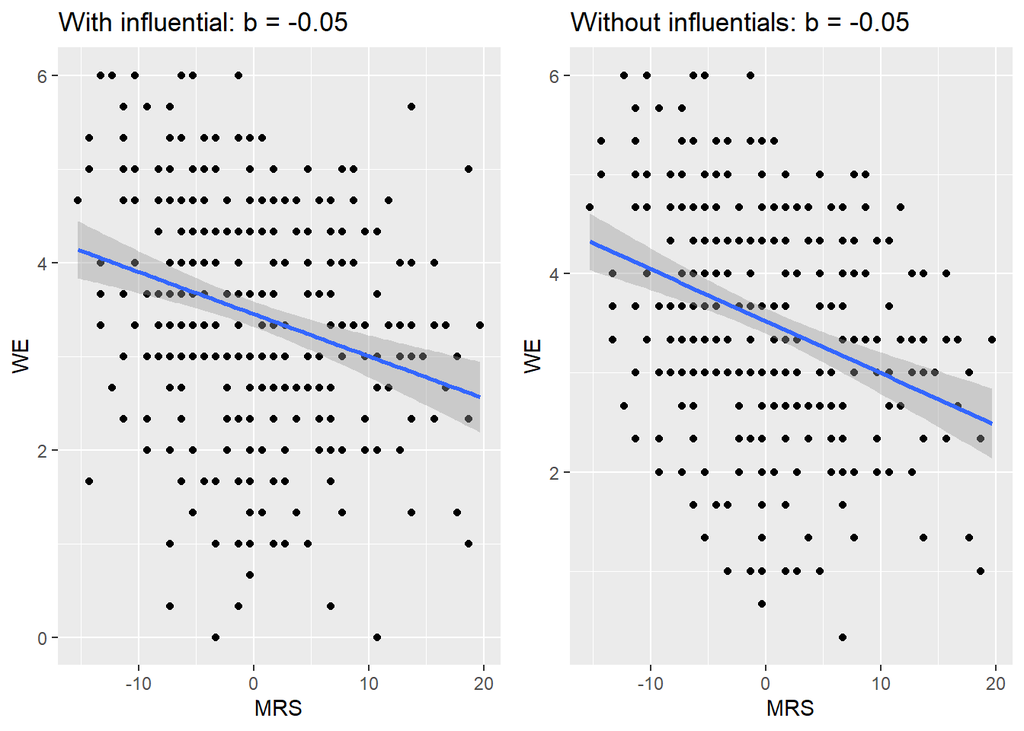

```r
# plotting effects with and without influential cases
influential <- as.integer(rownames(df[df$cd > (4/nrow(df)),]))
df2 <- df[-influential, ] # removing influential cases
p1 <- ggplot(data = df, aes(x = MRS, y = WE)) + geom_point() + geom_smooth(method = lm) +
  ggtitle(paste0("With influential: b = ",round(coefficients(WE.m3)[2],2)))
p2 <- ggplot(data = df2, aes(x = MRS, y = WE)) + geom_point() + geom_smooth(method = lm) +
  ggtitle(paste0("Without influentials: b = ",round(coefficients(update(WE.m3,data=df2))[2],2)))
gridExtra::grid.arrange(p1, p2, ncol=2)
```

Third, we compare the models by using the weight of the Akaike Information Criterion (Wagenmakers & Ferrel, 2004).

```r
Weights(AIC(WE.m0,WE.m1,WE.m2,WE.m3)) # model M3 is the best model
```

```
##  model weights
## [1] 0.000 0.001 0.039 0.961
```

```r
# print model output
tab_model(WE.m0,WE.m1,WE.m2,WE.m3, # all significant but health_conditions
          show.se=TRUE,collapse.se=TRUE,string.est="B (SE)",show.re.var = TRUE)
```

|  | WE |  |  | WE |  |  | WE |  |  | WE |  |  |
| --- | --- | --- | --- | --- | --- | --- | --- | --- | --- | --- | --- | --- |
| Predictors | B (SE) | CI | p | B (SE) | CI | p | B (SE) | CI | p | B (SE) | CI | p |
| (Intercept) | 3.45 (0.07) | 3.31 – 3.59 | **<0.001** | 3.45 (0.07) | 3.31 – 3.59 | **<0.001** | 3.45 (0.07) | 3.32 – 3.58 | **<0.001** | 3.47 (0.12) | 3.24 – 3.70 | **<0.001** |
| MRS |  |  |  | -0.04 (0.01) | -0.06 – -0.03 | **<0.001** | -0.05 (0.01) | -0.07 – -0.03 | **<0.001** | -0.05 (0.01) | -0.07 – -0.03 | **<0.001** |
| WL |  |  |  |  |  |  | 0.20 (0.06) | 0.08 – 0.33 | **0.002** | 0.19 (0.06) | 0.07 – 0.32 | **0.003** |
| age |  |  |  |  |  |  |  |  |  | 0.04 (0.01) | 0.02 – 0.07 | **0.001** |
| MHT [1] |  |  |  |  |  |  |  |  |  | -0.24 (0.19) | -0.62 – 0.14 | 0.213 |
| health conditions [Yes] |  |  |  |  |  |  |  |  |  | -0.19 (0.14) | -0.47 – 0.09 | 0.182 |
| caregiving [Yes] |  |  |  |  |  |  |  |  |  | 0.17 (0.14) | -0.10 – 0.44 | 0.225 |
| Observations | 310 |  |  | 310 |  |  | 310 |  |  | 310 |  |  |
| R<sup>2</sup> / R<sup>2</sup> adjusted | 0.000 / 0.000 |  |  | 0.074 / 0.071 |  |  | 0.103 / 0.097 |  |  | 0.144 / 0.127 |  |  |

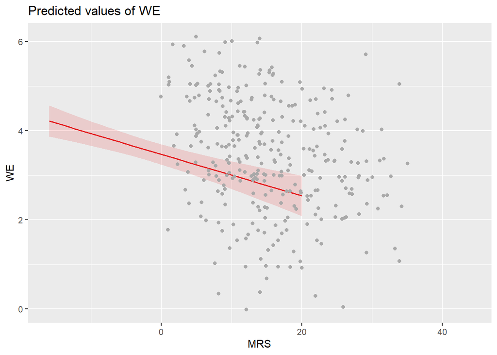

```r
# plotting MRS effect
plot_model(WE.m3,type="pred",terms="MRS") +
  geom_point(data=mp,aes(x=MRS,y=WE),color="darkgray",position=position_jitter())
```

## 7.3. Turnover intentions

First, we specify our models in a hierarchical manner on the list-wise-deleted dataset. Note that all continuous predictors are grand-mean-centered for better interpreting the model intercept.

```r
# list-wise deletion (removing all missing values in the considered variables)
df <- na.omit(mp[,c("TI","MRS","WL","age","MHT","health_conditions","caregiving")])
cat("Fitting models on",nrow(df),"observations")
```

```
## Fitting models on 301 observations
```

```r
# grand mean centering continuous predictors
df$MRS <- df$MRS - mean(df$MRS)
df$WL <- df$WL - mean(df$WL)
df$age <- df$age - mean(df$age)

# null model (no predictors)
TI.m0 <- lm(TI ~ 1, data = df)

# model M1 (menopause symptom severity)
TI.m1 <- lm(TI ~ MRS, data = df)

# model M2 (workload as a job demand)
TI.m2 <- lm(TI ~ MRS + WL, data = df)

# model M3 (covariates)
TI.m3 <- lm(TI ~ MRS + WL + age + MHT + health_conditions + caregiving, data = df)
```

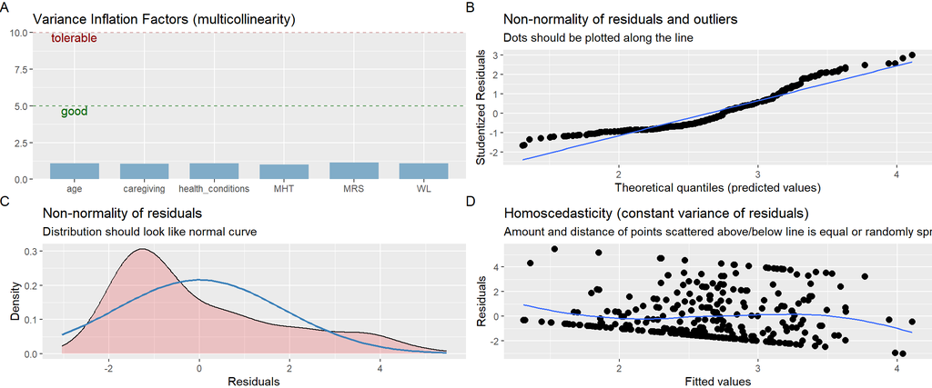

```r
p <- plot_model(TI.m3,type="diag")
plot_grid(p,tags=TRUE,margin=c(0,0,0,0))
```

```r
# skewness
library(moments)
skewness(df$TI)
```

```
## [1] 0.9879375
```

```r
# dichotomizing TI
df[df$TI < 2, "TI.dic"] <- 0
df[df$TI >= 2, "TI.dic"] <- 1
summary(as.factor(df$TI.dic)) # 150 vs 151
```

```
##   0   1
## 150 151
```

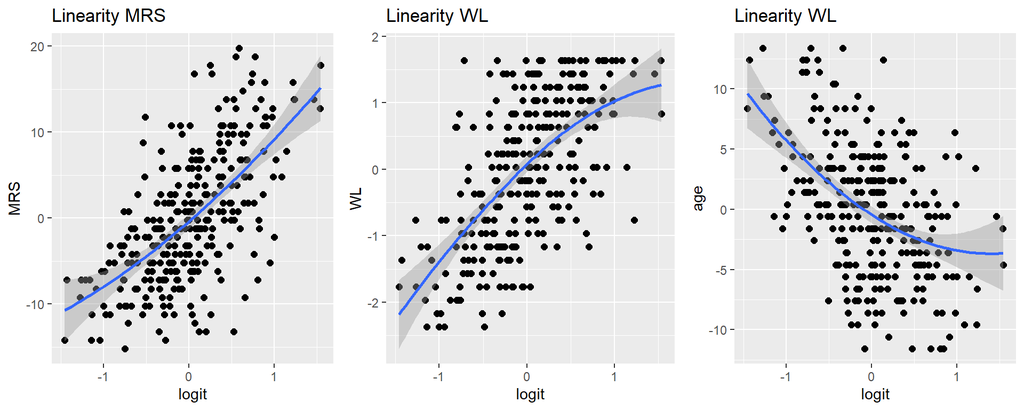

```r
# refitting models with logistic regression
TI.m0 <- glm(TI.dic ~ 1, data = df, family=binomial(link="logit"))
TI.m1 <- glm(TI.dic ~ MRS, data = df, family=binomial(link="logit"))
TI.m2 <- glm(TI.dic ~ MRS + WL, data = df, family=binomial(link="logit"))
TI.m3 <- glm(TI.dic ~ MRS + WL + age + MHT + health_conditions + caregiving, data = df, family=binomial(link="logit"))

# inspecting GLM diagnostics
df$probabilities <- predict(TI.m3, type = "response") # Predict the probability (p) of agreement
df$logit <- log(df$probabilities/(1-df$probabilities)) # from probability to logit
gridExtra::grid.arrange(ggplot(df, aes(logit,MRS))+geom_point(size=2)+
                          geom_smooth(method="loess",span=2)+
                          ggtitle("Linearity MRS"), # 1. linear rel. between continuous predictors & logit
                        ggplot(df, aes(logit,WL))+geom_point(size=2)+
                          geom_smooth(method="loess",span=2)+
                          ggtitle("Linearity WL"),
                        ggplot(df, aes(logit,age))+geom_point(size=2)+
                          geom_smooth(method="loess",span=2)+
                          ggtitle("Linearity WL"),nrow=1)
```

As a further diagnostic, we examine the impact of influential cases (i.e., based on the Cook’s distance) on the parameter estimated for `MRS.` We can see that several influential cases are detected, but none of them seem to substantially change the parameter estimated for `MRS`.

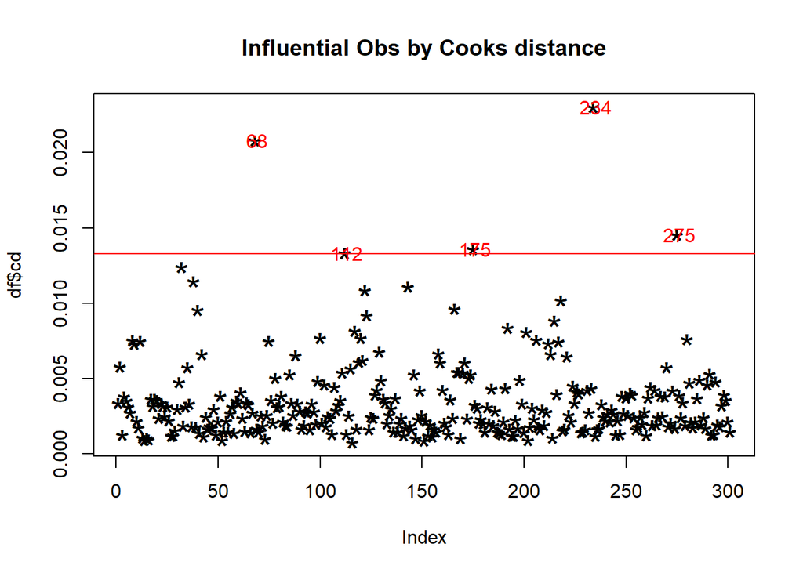

```r
# Cook's distances
df$cd <- cooks.distance(TI.m3)

# Plot the Cook's Distance using the traditional 4/n criterion
rownames(df) <- 1:nrow(df)
plot(df$cd, pch="*", cex=2, main="Influential Obs by Cooks distance")  # plot cook's distance
abline(h = 4/nrow(df), col="red")  # add cutoff line
text(x=1:nrow(df)+1, y=df$cd, labels=ifelse(df$cd>4/nrow(df), rownames(df),""), col="red")  # add labels
```